# lab-meeting

Lukas ‘hejtmy’ Hejtmanek

24 February 2018

# What

# Methods

## Overview

6 doors are ascribed to fictional workers: Emily, Michael, Daniel, Jesicca, Jacob and Sarah - Taken from the list of most used names in CA from 2000

4 pointing locations

## Design

Full experiemntal design with 4 possible conditions

- vr - vr
- real - vr
- vr - real
- real - real

## Procedure

Participants fill questionnaires

They do the virtualiser training regardless of their condition (even in real-to real)

Experiment has 2 phases, each has two parts: walking/pointing - Free roaming from door to door - all 6 ofices in 3 blocks (18 trials) - Pointing from 2 points to all 6 offices; exactly one office is always visible

Drawing blank map

## Settings

6 possible settings

Question: Should we run two same settings? To directly compare performance in the same sequence of goals and points?

# Participants

## Descriptives

## Number crunching

So far we:

- scheduled 56 timeslots
- administered 45 participants
- have 32 usable subjects
- wasted 5 working days

There are some issues with high dropout rate, so far about a 1/3

# Analysis

## Normalisation

Min normalising

# Results

## The bad

Unfortunatelly, out of 612 we have 202 not fully executed.

## Distance

Distance absolute

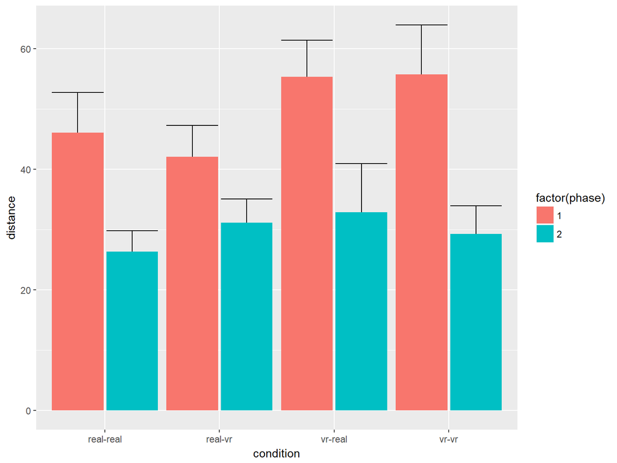

Distance normalised

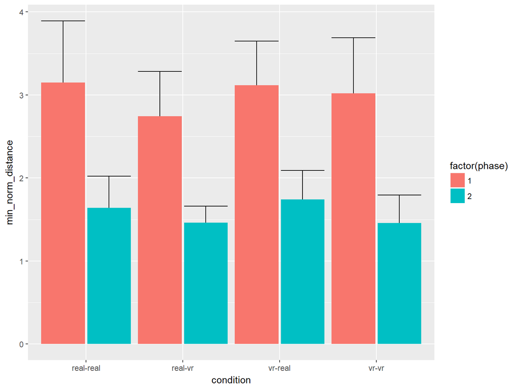

```r
walk_all %>%
  group_by(condition) %>%
  summarise(p.value = t.test(distance ~ phase)$p.value,
            phase1 = t.test(distance ~ phase)$estimate[[1]],
            phase2 = t.test(distance ~ phase)$estimate[[2]])
```

```
## # A tibble: 4 x 4
##   condition      p.value phase1 phase2
##   <chr>            <dbl>  <dbl>  <dbl>
## 1 real-real 0.000000640    46.0   26.3
## 2 real-vr   0.00107        42.0   31.1
## 3 vr-real   0.0000170      55.3   32.9
## 4 vr-vr     0.0000000950   55.7   29.3
```